# Lab 15: Regression Analysis II - Solutions

1. Load in the “massaged” Rossmann data. Create a variable that contains months of the year (Jan, Feb, …).

```r
library(tidyverse)
library(lubridate)
sales <- read_csv("rossmann_massaged.csv", col_types = cols(StateHoliday = col_character()))
sales$month <- month(sales$Date, label = TRUE)
sales$month <- factor(sales$month, ordered=FALSE)
```

```r
train <- filter(sales, Date < as.Date("2015-06-01"))
test <-  filter(sales, Date >= as.Date("2015-06-01"))
```

3. Add `av_sales` to your test and train data.

```r
av_sales <- train %>% group_by(Store) %>% summarize(av_sales=mean(Sales))
#merge those average sales into the test and train data
test <- inner_join(test, av_sales, by="Store")
train <- inner_join(train, av_sales, by="Store")
```

4. Add the month variable to regression 4 above using the training data. Describe the results.

```r
reg5 <- lm(Sales ~ day + competition + before + after + av_sales + month, data=train)
summary(reg5)
```

```
##
## Call:
## lm(formula = Sales ~ day + competition + before + after + av_sales +
##     month, data = train)
##
## Residuals:
##      Min       1Q   Median       3Q      Max
## -17668.8  -1122.8    -38.5   1002.1  26948.9
##
## Coefficients:
##                  Estimate Std. Error  t value Pr(>|t|)
## (Intercept)    -1.580e+02  1.139e+01  -13.867  < 2e-16 ***
## dayMon          1.151e+03  7.018e+00  163.998  < 2e-16 ***
## daySat         -1.174e+03  6.873e+00 -170.859  < 2e-16 ***
## daySun         -6.786e+02  3.098e+01  -21.907  < 2e-16 ***
## dayThu         -2.713e+02  7.052e+00  -38.465  < 2e-16 ***
## dayTue         -4.381e+01  6.900e+00   -6.349 2.17e-10 ***
## dayWed         -3.585e+02  6.999e+00  -51.217  < 2e-16 ***
## competitionyes -1.302e+02  6.913e+00  -18.833  < 2e-16 ***
## beforeyes       6.834e+02  1.293e+01   52.842  < 2e-16 ***
## afteryes        8.546e+02  1.109e+01   77.071  < 2e-16 ***
## av_sales        1.000e+00  8.272e-04 1209.162  < 2e-16 ***
## monthFeb        5.610e+01  8.662e+00    6.476 9.40e-11 ***
## monthMar        4.168e+02  8.506e+00   49.004  < 2e-16 ***
## monthApr        4.472e+02  8.647e+00   51.713  < 2e-16 ***
## monthMay        4.839e+02  8.712e+00   55.547  < 2e-16 ***
## monthJun        2.839e+02  9.668e+00   29.362  < 2e-16 ***
## monthJul        3.318e+02  9.615e+00   34.509  < 2e-16 ***
## monthAug        1.196e+02  9.664e+00   12.373  < 2e-16 ***
## monthSep       -6.577e+01  9.786e+00   -6.721 1.81e-11 ***
## monthOct       -2.414e+01  9.740e+00   -2.479   0.0132 *
## monthNov        6.373e+02  9.828e+00   64.846  < 2e-16 ***
## monthDec        1.895e+03  9.945e+00  190.511  < 2e-16 ***
## ---
## Signif. codes:  0 '***' 0.001 '**' 0.01 '*' 0.05 '.' 0.1 ' ' 1
##
## Residual standard error: 1763 on 785759 degrees of freedom
## Multiple R-squared:  0.6773, Adjusted R-squared:  0.6773
## F-statistic: 7.855e+04 on 21 and 785759 DF,  p-value: < 2.2e-16
```

We see that all of the monthly dummies are statitically significant, telling as that there are seasonal differences in sales. Specifically, sales seem much higher in November and December relative to January; September and October tend to be slow months. The variables in the regression explain almost 68% of the variation in sales.

5. What is the interpretation of the coefficient on `monthDecember`?

Controlling for day of the week, competition and whether it is the day after or before holidays, sales in December are about 1,900 euros higher than in January. The effect is statistically significant.

6. Make sales predictions on test data using your regression from q2. Calculate root mean square error. Do you do better than we did in class?

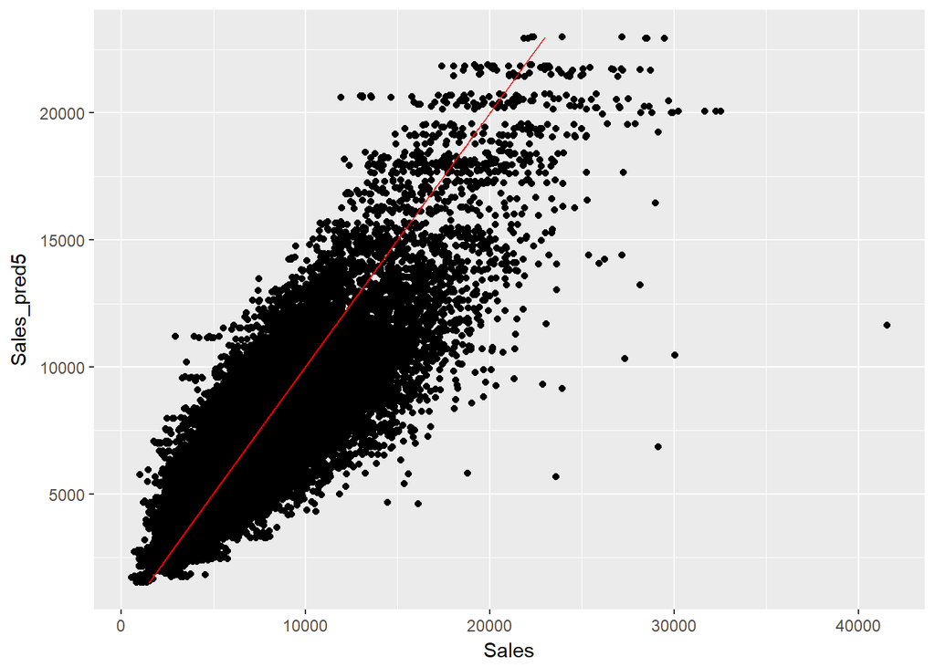

```r
test$Sales_pred5 <- predict(reg5, test)
ggplot(test, aes(y=Sales_pred5, x=Sales)) + geom_point() + geom_line(aes(y=Sales_pred5,x=Sales_pred5), color="red")
```

```r
sqrt(mean(((test$Sales-test$Sales_pred5)/test$Sales)^2))
```

```
## [1] 0.2650328
```

This is slightly better than what we had in class.

7. Can you improve on these predictions further? Have fun with the data, and report your results.

Let’s use `promo` to see if promotions predict sales.

```r
reg6 <- lm(Sales ~ day + competition + before + after + av_sales + month + Promo, data=train)
summary(reg6)
```

```
##
## Call:
## lm(formula = Sales ~ day + competition + before + after + av_sales +
##     month + Promo, data = train)
##
## Residuals:
##      Min       1Q   Median       3Q      Max
## -16620.1   -807.1    -80.5    702.9  26377.6
##
## Coefficients:
##                  Estimate Std. Error  t value Pr(>|t|)
## (Intercept)    -1.390e+03  9.362e+00 -148.483  < 2e-16 ***
## dayMon          1.084e+03  5.650e+00  191.898  < 2e-16 ***
## daySat          4.688e+01  5.840e+00    8.027 9.97e-16 ***
## daySun          5.640e+02  2.501e+01   22.551  < 2e-16 ***
## dayThu         -3.278e+02  5.677e+00  -57.741  < 2e-16 ***
## dayTue         -7.386e+01  5.555e+00  -13.298  < 2e-16 ***
## dayWed         -3.732e+02  5.634e+00  -66.248  < 2e-16 ***
## competitionyes -1.420e+02  5.564e+00  -25.511  < 2e-16 ***
## beforeyes       8.058e+02  1.041e+01   77.395  < 2e-16 ***
## afteryes        1.429e+03  8.969e+00  159.368  < 2e-16 ***
## av_sales        1.000e+00  6.659e-04 1502.219  < 2e-16 ***
## monthFeb        1.523e+02  6.974e+00   21.833  < 2e-16 ***
## monthMar        3.376e+02  6.848e+00   49.300  < 2e-16 ***
## monthApr        3.856e+02  6.961e+00   55.388  < 2e-16 ***
## monthMay        3.810e+02  7.014e+00   54.314  < 2e-16 ***
## monthJun        3.230e+02  7.782e+00   41.499  < 2e-16 ***
## monthJul        3.011e+02  7.740e+00   38.908  < 2e-16 ***
## monthAug        1.456e+02  7.779e+00   18.715  < 2e-16 ***
## monthSep        1.568e+01  7.878e+00    1.990   0.0466 *
## monthOct        4.368e+01  7.840e+00    5.571 2.53e-08 ***
## monthNov        5.192e+02  7.913e+00   65.611  < 2e-16 ***
## monthDec        1.982e+03  8.006e+00  247.530  < 2e-16 ***
## Promo           2.330e+03  3.565e+00  653.440  < 2e-16 ***
## ---
## Signif. codes:  0 '***' 0.001 '**' 0.01 '*' 0.05 '.' 0.1 ' ' 1
##
## Residual standard error: 1419 on 785758 degrees of freedom
## Multiple R-squared:  0.7909, Adjusted R-squared:  0.7909
## F-statistic: 1.351e+05 on 22 and 785758 DF,  p-value: < 2.2e-16
```

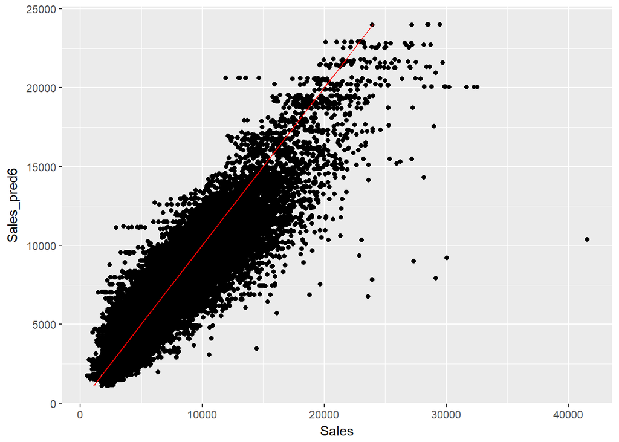

```r
test$Sales_pred6 <- predict(reg6, test)
ggplot(test, aes(y=Sales_pred6, x=Sales)) + geom_point() + geom_line(aes(y=Sales_pred6,x=Sales_pred6), color="red")
```

```r
sqrt(mean(((test$Sales-test$Sales_pred6)/test$Sales)^2))
```

```
## [1] 0.2174749
```

Again, we improved just a bit from the previous model.